# Airbnb in London - Initial data exploration and simple price analysis

Webster

First, we load the useful packages.

# 1 Downloading the data

We go and download the data where it is, on the InsideAirbnb website. We choose to download the data from July 2019 for London (pre-pandemic).

```r
# ## Requires internet connection
# download.file(
#   "http://data.insideairbnb.com/united-kingdom/england/london/2019-07-10/data/listings.csv.gz",
#   here("01. Raw"","listings.csv.gz"))
#
# download.file(
#   "http://data.insideairbnb.com/united-kingdom/england/london/2019-07-10/data/calendar.csv.gz",
#   here("01. Raw","calendar.csv.gz"))
#
# download.file(
#   "http://data.insideairbnb.com/united-kingdom/england/london/2019-07-10/data/reviews.csv.gz",
#   here("01. Raw","reviews.csv.gz"))
#
# download.file(
#   "http://data.insideairbnb.com/united-kingdom/england/london/2019-07-10/visualisations/neighbourhoods.geojson",
#   here("01. Raw","neighbourhoods.geojson"))
```

Now that we have downloaded the data, we open the different files and store them into R objects. Note that we do not need to unzip the files, it is done on the fly.

Let’s see what these datasets look like. - Listings: shows characteristics and price posted by 83,850 listings in July 2019 in London. Of particular interest is precise location, descriptions, and number of reviews - Calendar: shows for each date in the calendar and each listing (30 million observations) if the day is available, how much it costs, and the number of bookable nights - Reviews: 1.4 million reviews available for these listings. - Neighbourhoods: this is a geographic dataset with the contours of London boroughs.

```r
listdb %>% head
```

```
## # A tibble: 6 × 106
##      id listing_url  scrape_id last_scraped name   summary   space  description
##   <dbl> <chr>            <dbl> <date>       <chr>  <chr>     <chr>  <chr>
## 1 13913 https://www…   2.02e13 2019-07-11   Holid… My brigh… Hello… My bright d…
## 2 15400 https://www…   2.02e13 2019-07-11   Brigh… Lots of … Brigh… Lots of win…
## 3 17402 https://www…   2.02e13 2019-07-11   Super… Open fro… Ready… Open from J…
## 4 24328 https://www…   2.02e13 2019-07-11   Batte… Artist h… - End… Artist hous…
## 5 25023 https://www…   2.02e13 2019-07-11   All-c… Large, a… 10 mi… Large, all …
## 6 25123 https://www…   2.02e13 2019-07-11   Clean… Big room… Big d… Big room wi…
## # … with 98 more variables: experiences_offered <chr>,
## #   neighborhood_overview <chr>, notes <chr>, transit <chr>, access <chr>,
## #   interaction <chr>, house_rules <chr>, thumbnail_url <lgl>,
## #   medium_url <lgl>, picture_url <chr>, xl_picture_url <lgl>, host_id <dbl>,
## #   host_url <chr>, host_name <chr>, host_since <date>, host_location <chr>,
## #   host_about <chr>, host_response_time <chr>, host_response_rate <chr>,
## #   host_acceptance_rate <chr>, host_is_superhost <lgl>, …
```

```r
caldb %>% head
```

```
## # A tibble: 6 × 7
##   listing_id date       available price  adjusted_price minimum_nights
##        <dbl> <date>     <lgl>     <chr>  <chr>                   <dbl>
## 1      78892 2019-07-12 FALSE     $36.00 $36.00                      3
## 2      78892 2019-07-13 FALSE     $36.00 $36.00                      3
## 3      78892 2019-07-14 FALSE     $36.00 $36.00                      3
## 4      78892 2019-07-15 FALSE     $32.00 $32.00                      3
## 5      78892 2019-07-16 FALSE     $32.00 $32.00                      3
## 6      78892 2019-07-17 FALSE     $32.00 $32.00                      3
## # … with 1 more variable: maximum_nights <dbl>
```

```r
revdb %>% head
```

```
## # A tibble: 6 × 6
##   listing_id      id date       reviewer_id reviewer_name comments
##        <dbl>   <dbl> <date>           <dbl> <chr>         <chr>
## 1      13913   80770 2010-08-18      177109 Michael       "My girlfriend and I …
## 2      13913  367568 2011-07-11    19835707 Mathias       "Alina was a really g…
## 3      13913  529579 2011-09-13     1110304 Kristin       "Alina is an amazing …
## 4      13913  595481 2011-10-03     1216358 Camilla       "Alina's place is so …
## 5      13913  612947 2011-10-09      490840 Jorik         "Nice location in Isl…
## 6      13913 4847959 2013-05-28     6405442 Vera          "I'm very happy to ha…
```

```r
neighdb %>% head
```

```
##          neighbourhood neighbourhood_group
## 1 Kingston upon Thames                <NA>
## 2              Croydon                <NA>
## 3              Bromley                <NA>
## 4             Hounslow                <NA>
## 5               Ealing                <NA>
## 6             Havering                <NA>
##                                                                                                                                                                                                                                                                                                          …
## 1                                                                                                                                                                                                                                                                                                        …
## 2                                                                                                                                                                                                                                                                                                        …
## 3 0.012131, 0.011962, 0.011882, 0.011803, 0.011750, 0.011682, 0.011618, 0.011539, 0.011489, 0.011415, 0.011323, 0.011248, 0.011186, 0.011099, 0.011036, 0.011071, 0.011053, 0.011072, 0.010950, 0.010913, 0.010874, 0.010801, 0.010838, 0.010833, 0.010779, 0.010621, 0.010503, 0.010485, 0.010451, 0.010…
## 4                                                                                                                                                                                                                                                                                                        …
## 5                                                                                                                                                                                                                                                                                                        …
## 6                                                                                                                                                                                                                                                                                                        …
```

# 2 Mapping the data

Let’s map the neighbourhoods. Yes, it looks like London, indeed.

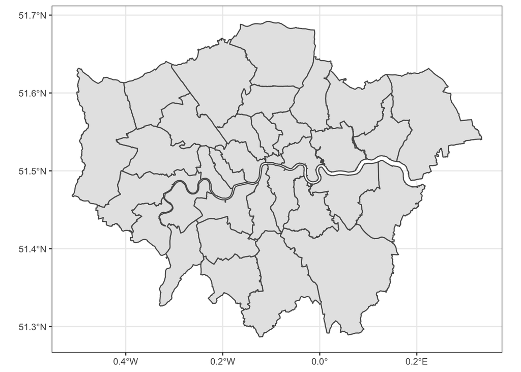

```r
neighdb %>% ggplot() + geom_sf() +
  theme_bw()
```

Let’s now put the listings on top of the previous map. We adjust the transparancy to make a “heatmap” - this allows us to have a better idea of the areas where listings are mostly located. The map confirms that listings are in central London, not much in the periphery of London.

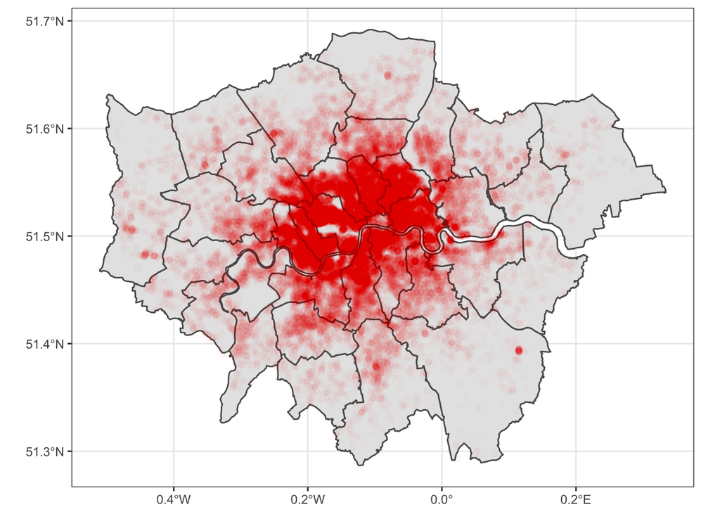

```r
#converting the longitude and latitude in lisdb to sf format to feed into ggplot
listsf <- listdb %>% sf::st_as_sf(coords = c("longitude", "latitude"), crs = 4326)

ggplot(listsf) +
  geom_sf(data = neighdb) +
  geom_sf(alpha=.01, inherit.aes =FALSE, color = "red")+
  theme_bw()
```

Let’s now zoom in on Central London. This map is clearer indeed. One can guess parks and areas more sparsely populated.

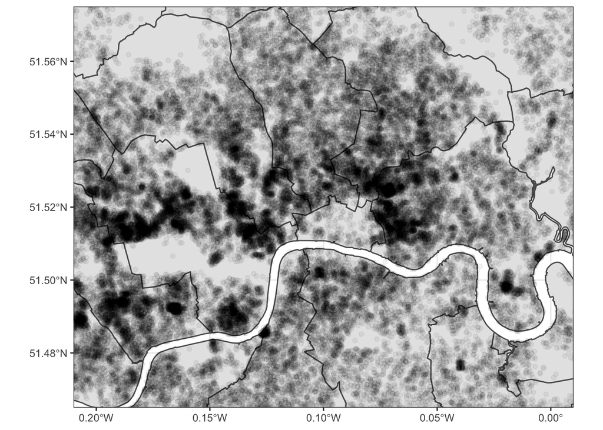

```r
ggplot(listsf) +
  geom_sf(data = neighdb) +
  geom_sf(alpha=.05, inherit.aes =FALSE) +
  coord_sf(xlim=c(-.2,0),ylim=c(51.47,51.57)) +
  theme_bw()
```

# 3 Amenities

An interesting pattern in the data is that we know all the amenities that hosts are listing about their properties. There are hundreds of them and they might be important to understand how hosts price their properties.

We first unpack the list of amenities and keep the ones that appear enough times (we take a threshold of 200).

```r
listdb <- listdb %>%
  mutate(amen = amenities %>%
           str_replace_all("[-/ ]","_") %>%         #match either - or / or space and replace with _
           str_remove_all("[()’]") %>%              #remove all ( or ) or '
           str_replace_all("24_hour","H24") %>%     # replace 24_hour with H24
           str_to_lower())                          #lowercase

amen_unpacked <- listdb %>% pull(amen) %>%
  str_remove_all("[{}]") %>% str_remove_all('\\"') %>% str_split(",")

#Remove automated messages
list_amen <- tibble(amen = do.call("c", amen_unpacked)) %>% count(amen) %>% filter(n>200) %>% pull(amen) %>% setdiff(c("","_toilet","translation_missing:_en.hosting_amenity_49","translation_missing:_en.hosting_amenity_50"))
```

The object `list_amen` that we have created contains 116 amenities that are frequently used. Now, we create a dataset with the same number of observations as the number of listings, with dummy variables for each amenity.

```r
amen_dummy_fun <- function(amenity) {
  amen_unpacked %>%
    map_lgl(function(vv){any(amenity==vv)})
  }

listdb2 <- list_amen %>% map(amen_dummy_fun)
names(listdb2) <- list_amen
listdb2 <- listdb2 %>% as_tibble()
listdb2 %>% head
```

```
## # A tibble: 6 × 116
##   accessible_height_bed accessible_heig… air_conditioning baby_bath baby_monitor
##   <lgl>                 <lgl>            <lgl>            <lgl>     <lgl>
## 1 TRUE                  TRUE             FALSE            FALSE     FALSE
## 2 FALSE                 FALSE            TRUE             FALSE     FALSE
## 3 FALSE                 FALSE            FALSE            FALSE     FALSE
## 4 FALSE                 FALSE            FALSE            FALSE     FALSE
## 5 FALSE                 FALSE            FALSE            FALSE     FALSE
## 6 FALSE                 FALSE            FALSE            FALSE     FALSE
## # … with 111 more variables: babysitter_recommendations <lgl>,
## #   bath_towel <lgl>, bathroom_essentials <lgl>, bathtub <lgl>,
## #   bbq_grill <lgl>, bed_linens <lgl>, bedroom_comforts <lgl>, body_soap <lgl>,
## #   breakfast <lgl>, building_staff <lgl>, buzzer_wireless_intercom <lgl>,
## #   cable_tv <lgl>, carbon_monoxide_detector <lgl>, cats <lgl>,
## #   changing_table <lgl>, childrens_books_and_toys <lgl>,
## #   childrens_dinnerware <lgl>, cleaning_before_checkout <lgl>, …
```

Now let’s turn to the property_type variable, it has way too many values, we’ll need to simplify it a bit. We do that below.

```r
listdb %>% count(property_type) %>% arrange(desc(n))
```

```
## # A tibble: 40 × 2
##    property_type          n
##    <chr>              <int>
##  1 Apartment          56802
##  2 House              17436
##  3 Townhouse           2979
##  4 Serviced apartment  1896
##  5 Condominium         1107
##  6 Bed and breakfast    877
##  7 Loft                 715
##  8 Guest suite          356
##  9 Guesthouse           279
## 10 Hostel               231
## # … with 30 more rows
```

What about the neighbourhood and neighbourhood_cleansed variables. What do they look like?

```r
listdb %>% count(neighbourhood) %>% arrange(desc(n))
```

```
## # A tibble: 151 × 2
##    neighbourhood                    n
##    <chr>                        <int>
##  1 City of Westminster           5294
##  2 LB of Tower Hamlets           4548
##  3 LB of Islington               3821
##  4 LB of Hackney                 3751
##  5 LB of Camden                  3112
##  6 RB of Kensington and Chelsea  2533
##  7 LB of Southwark               2519
##  8 LB of Wandsworth              2467
##  9 LB of Brent                   2434
## 10 LB of Lambeth                 2402
## # … with 141 more rows
```

```r
listdb %>% count(neighbourhood_cleansed) %>% arrange(desc(n))
```

```
## # A tibble: 33 × 2
##    neighbourhood_cleansed     n
##    <chr>                  <int>
##  1 Westminster             9411
##  2 Tower Hamlets           8024
##  3 Hackney                 6116
##  4 Camden                  5968
##  5 Kensington and Chelsea  5852
##  6 Islington               5156
##  7 Southwark               4886
##  8 Lambeth                 4807
##  9 Wandsworth              4262
## 10 Hammersmith and Fulham  4209
## # … with 23 more rows
```

# 4 Modelling prices using simple linear regressions

Based on the ground work above, we build the regression dataset, where we clean a few variables, add the dummy variables for amenities, and remove one zero-price observation.

```r
regdb <- listdb %>%
  mutate(price = price %>% str_sub(2,-1) %>% str_remove_all(",") %>% as.numeric(),
         log_price = log(price),
         square_feet_na = is.na(square_feet),
         square_feet = ifelse(is.na(square_feet),0,square_feet),
         property_type = ifelse(property_type %in% c("Apartment","House","Townhouse","Serviced apartment"),property_type,"Other")) %>%
  select(id, log_price, square_feet, square_feet_na, property_type, room_type,
         accommodates, bathrooms, bedrooms, beds, bed_type,neighbourhood) %>%
  bind_cols(listdb2) %>%
  filter(is.finite(log_price))
```

Now, we run the regressions. We run three specifications: - A simple one with just a few variables, - A more involved one with amenities, - The biggest one with amenities and neighbourhood fixed effects.

```r
price_formula <- formula("log_price ~ property_type + room_type + accommodates + bathrooms + bedrooms + beds + bed_type + square_feet + square_feet_na")

price_formula_big <- paste0("log_price ~ property_type + room_type + accommodates + bathrooms + bedrooms + beds + bed_type + square_feet + square_feet_na +",
                        paste(list_amen, collapse= " + ")) %>% formula()

price_formula_big_neigh <- paste0("log_price ~ property_type + room_type + accommodates + bathrooms + bedrooms + beds + bed_type + square_feet + square_feet_na +",
                        paste(list_amen, collapse= " + "), "| neighbourhood") %>% formula()

res <- felm(price_formula, regdb)
res %>% summary
```

```
##
## Call:
##    felm(formula = price_formula, data = regdb)
##
## Residuals:
##     Min      1Q  Median      3Q     Max
## -5.1394 -0.3172 -0.0576  0.2500  5.1997
##
## Coefficients:
##                                   Estimate Std. Error  t value Pr(>|t|)
## (Intercept)                      4.159e+00  8.209e-02   50.673  < 2e-16 ***
## property_typeHouse              -1.510e-01  4.938e-03  -30.577  < 2e-16 ***
## property_typeOther               1.416e-01  8.046e-03   17.594  < 2e-16 ***
## property_typeServiced apartment  2.415e-01  1.224e-02   19.730  < 2e-16 ***
## property_typeTownhouse          -1.050e-01  1.003e-02  -10.473  < 2e-16 ***
## room_typePrivate room           -7.057e-01  4.715e-03 -149.652  < 2e-16 ***
## room_typeShared room            -1.038e+00  2.008e-02  -51.697  < 2e-16 ***
## accommodates                     1.057e-01  1.878e-03   56.290  < 2e-16 ***
## bathrooms                        1.295e-01  3.723e-03   34.788  < 2e-16 ***
## bedrooms                         1.313e-01  3.430e-03   38.270  < 2e-16 ***
## beds                            -4.567e-02  2.596e-03  -17.592  < 2e-16 ***
## bed_typeCouch                   -1.959e-01  9.789e-02   -2.001 0.045426 *
## bed_typeFuton                   -1.625e-01  8.519e-02   -1.907 0.056539 .
## bed_typePull-out Sofa           -9.813e-02  8.024e-02   -1.223 0.221394
## bed_typeReal Bed                 2.667e-02  7.619e-02    0.350 0.726293
## square_feet                      9.732e-05  2.711e-05    3.590 0.000331 ***
## square_feet_naTRUE              -3.798e-02  3.100e-02   -1.225 0.220586
## ---
## Signif. codes:  0 '***' 0.001 '**' 0.01 '*' 0.05 '.' 0.1 ' ' 1
##
## Residual standard error: 0.522 on 83563 degrees of freedom
##   (251 observations deleted due to missingness)
## Multiple R-squared(full model): 0.5606   Adjusted R-squared: 0.5605
## Multiple R-squared(proj model): 0.5606   Adjusted R-squared: 0.5605
## F-statistic(full model): 6662 on 16 and 83563 DF, p-value: < 2.2e-16
## F-statistic(proj model):  6662 on 16 and 83563 DF, p-value: < 2.2e-16
```

```r
resb <- felm(price_formula_big, regdb)
resb %>% summary
```

```
##
## Call:
##    felm(formula = price_formula_big, data = regdb)
##
## Residuals:
##     Min      1Q  Median      3Q     Max
## -4.8437 -0.2903 -0.0363  0.2422  5.2707
##
## Coefficients:
##                                      Estimate Std. Error  t value Pr(>|t|)
## (Intercept)                         4.363e+00  7.694e-02   56.705  < 2e-16 ***
## property_typeHouse                 -7.275e-02  5.002e-03  -14.544  < 2e-16 ***
## property_typeOther                  1.158e-01  7.723e-03   14.998  < 2e-16 ***
## property_typeServiced apartment     1.406e-01  1.167e-02   12.051  < 2e-16 ***
## property_typeTownhouse             -2.696e-02  9.648e-03   -2.794 0.005200 **
## room_typePrivate room              -6.314e-01  4.915e-03 -128.455  < 2e-16 ***
## room_typeShared room               -1.014e+00  1.890e-02  -53.688  < 2e-16 ***
## accommodates                        9.300e-02  1.782e-03   52.189  < 2e-16 ***
## bathrooms                           8.123e-02  3.520e-03   23.079  < 2e-16 ***
## bedrooms                            1.352e-01  3.267e-03   41.391  < 2e-16 ***
## beds                               -3.640e-02  2.424e-03  -15.016  < 2e-16 ***
## bed_typeCouch                      -1.827e-01  9.070e-02   -2.015 0.043951 *
## bed_typeFuton                      -1.103e-01  7.893e-02   -1.398 0.162188
## bed_typePull-out Sofa              -6.528e-02  7.435e-02   -0.878 0.379928
## bed_typeReal Bed                    2.500e-02  7.060e-02    0.354 0.723317
## square_feet                         1.012e-04  2.513e-05    4.028 5.63e-05 ***
## square_feet_naTRUE                 -4.784e-02  2.886e-02   -1.658 0.097355 .
## accessible_height_bedTRUE          -2.907e-02  1.635e-02   -1.778 0.075429 .
## accessible_height_toiletTRUE       -3.869e-02  1.788e-02   -2.164 0.030495 *
## air_conditioningTRUE                2.743e-01  7.346e-03   37.338  < 2e-16 ***
## baby_bathTRUE                      -2.620e-02  2.162e-02   -1.212 0.225495
## baby_monitorTRUE                   -7.870e-02  2.940e-02   -2.677 0.007432 **
## babysitter_recommendationsTRUE      1.320e-01  1.428e-02    9.243  < 2e-16 ***
## bath_towelTRUE                      4.897e-01  4.837e-01    1.012 0.311309
## bathroom_essentialsTRUE                   NaN         NA      NaN      NaN
## bathtubTRUE                        -3.493e-03  7.116e-03   -0.491 0.623549
## bbq_grillTRUE                      -1.898e-02  1.121e-02   -1.693 0.090501 .
## bed_linensTRUE                     -3.265e-02  5.773e-03   -5.656 1.55e-08 ***
## bedroom_comfortsTRUE                1.609e-01  9.296e-02    1.731 0.083538 .
## body_soapTRUE                             NaN         NA      NaN      NaN
```

[output cut: 97 more lines]

```
## wide_entranceTRUE                  -1.745e-03  1.933e-02   -0.090 0.928083
## wide_entrance_for_guestsTRUE       -3.102e-02  1.497e-02   -2.072 0.038289 *
## wide_entrywayTRUE                   6.624e-03  1.798e-02    0.369 0.712494
## wide_hallwaysTRUE                  -1.584e-02  1.283e-02   -1.235 0.216853
## wifiTRUE                            2.205e-03  9.286e-03    0.237 0.812316
## window_guardsTRUE                  -4.069e-02  2.002e-02   -2.032 0.042153 *
## ---
## Signif. codes:  0 '***' 0.001 '**' 0.01 '*' 0.05 '.' 0.1 ' ' 1
##
## Residual standard error: 0.4833 on 83449 degrees of freedom
##   (251 observations deleted due to missingness)
## Multiple R-squared(full model): 0.6238   Adjusted R-squared: 0.6232
## Multiple R-squared(proj model): 0.6238   Adjusted R-squared: 0.6232
## F-statistic(full model): 1065 on 130 and 83449 DF, p-value: < 2.2e-16
## F-statistic(proj model): 396.6 on 132 and 83449 DF, p-value: < 2.2e-16
```

```r
resbf <- felm(price_formula_big_neigh, regdb)
resbf %>% summary
```

```
##
## Call:
##    felm(formula = price_formula_big_neigh, data = regdb)
##
## Residuals:
##     Min      1Q  Median      3Q     Max
## -4.9289 -0.2618 -0.0340  0.2133  5.2455
##
## Coefficients:
##                                      Estimate Std. Error  t value Pr(>|t|)
## property_typeHouse                  7.254e-05  4.772e-03    0.015 0.987871
## property_typeOther                  1.519e-01  7.234e-03   21.003  < 2e-16 ***
## property_typeServiced apartment     1.425e-01  1.095e-02   13.019  < 2e-16 ***
## property_typeTownhouse              1.171e-02  9.037e-03    1.296 0.194997
## room_typePrivate room              -5.799e-01  4.631e-03 -125.221  < 2e-16 ***
## room_typeShared room               -9.570e-01  1.767e-02  -54.164  < 2e-16 ***
## accommodates                        8.600e-02  1.672e-03   51.445  < 2e-16 ***
## bathrooms                           5.646e-02  3.303e-03   17.095  < 2e-16 ***
## bedrooms                            1.493e-01  3.065e-03   48.717  < 2e-16 ***
## beds                               -3.083e-02  2.267e-03  -13.599  < 2e-16 ***
## bed_typeCouch                      -2.210e-01  8.465e-02   -2.611 0.009037 **
## bed_typeFuton                      -1.643e-01  7.366e-02   -2.231 0.025691 *
## bed_typePull-out Sofa              -1.094e-01  6.939e-02   -1.577 0.114740
## bed_typeReal Bed                   -3.082e-02  6.588e-02   -0.468 0.639916
## square_feet                         9.264e-05  2.344e-05    3.952 7.76e-05 ***
## square_feet_naTRUE                 -5.123e-02  2.694e-02   -1.902 0.057183 .
## accessible_height_bedTRUE          -2.544e-02  1.526e-02   -1.667 0.095499 .
## accessible_height_toiletTRUE       -5.538e-02  1.670e-02   -3.316 0.000914 ***
## air_conditioningTRUE                2.109e-01  6.909e-03   30.522  < 2e-16 ***
## baby_bathTRUE                       1.973e-04  2.019e-02    0.010 0.992200
## baby_monitorTRUE                   -8.055e-02  2.746e-02   -2.933 0.003361 **
## babysitter_recommendationsTRUE      9.758e-02  1.334e-02    7.314 2.61e-13 ***
## bath_towelTRUE                      3.810e-01  4.511e-01    0.844 0.398413
## bathroom_essentialsTRUE                   NaN         NA      NaN      NaN
## bathtubTRUE                        -5.124e-04  6.646e-03   -0.077 0.938544
## bbq_grillTRUE                      -1.711e-03  1.048e-02   -0.163 0.870306
## bed_linensTRUE                     -4.464e-02  5.398e-03   -8.270  < 2e-16 ***
## bedroom_comfortsTRUE                1.576e-01  8.675e-02    1.817 0.069234 .
## body_soapTRUE                             NaN         NA      NaN      NaN
## breakfastTRUE                       8.549e-03  4.850e-03    1.763 0.077956 .
```

[output cut: 96 more lines]

```
## wide_entranceTRUE                  -2.692e-03  1.805e-02   -0.149 0.881463
## wide_entrance_for_guestsTRUE       -3.061e-02  1.398e-02   -2.189 0.028570 *
## wide_entrywayTRUE                   9.899e-03  1.678e-02    0.590 0.555312
## wide_hallwaysTRUE                  -2.085e-02  1.198e-02   -1.740 0.081834 .
## wifiTRUE                           -1.168e-02  8.678e-03   -1.346 0.178193
## window_guardsTRUE                  -3.342e-02  1.870e-02   -1.787 0.073987 .
## ---
## Signif. codes:  0 '***' 0.001 '**' 0.01 '*' 0.05 '.' 0.1 ' ' 1
##
## Residual standard error: 0.4507 on 83299 degrees of freedom
##   (252 observations deleted due to missingness)
## Multiple R-squared(full model): 0.6734   Adjusted R-squared: 0.6723
## Multiple R-squared(proj model): 0.5908   Adjusted R-squared: 0.5894
## F-statistic(full model):615.5 on 279 and 83299 DF, p-value: < 2.2e-16
## F-statistic(proj model): 300.3 on 132 and 83299 DF, p-value: < 2.2e-16
```